# scicur-study1

# Libraries

```r
library(rio)
library(here)
library(tidyverse)
library(janitor)
library(ggplot2)
```

# Import Joined Data (df1)

Loading a single dataframe that has already been prepped in a different document. It includes both the baseline and study 1 data, matched by MTurk ID.

It is already excluding:

- Duplicates
- Unfinished responses
- Responses where Ss reported cheating
- Responses where Ss reported bad response
- Unapproved responses
- Responses where Ss did not consent
- Responses that were not in both dfs (b and s1)

```r
df1 <- import(here("prepped-data", "joined-data.csv"))
```

## N (df1)

```r
df1 %>%
  nrow()
```

```
## [1] 545
```

# Cleaning (df2)

```r
df2 <- df1 %>%
  select(id, batch, contains("duration_in_seconds"), contains("2_1_sc"),
         contains("news1"), contains("act"), contains("books"), contains("convo"),
         contains("share_freq"), contains("read_article"), contains("topic_interest"),
         contains("1_1_sc"), contains("time_page_submit_sc"),
         contains("rav"), contains("cc_risk"), contains("ccr"),
         contains("dem"), contains("start_date"), contains("end_date"),
         contains("finished"), contains("consent"), contains("open"), contains("fl_")
         )
```

```r
df2[3:170] <- lapply(df2[3:170], as.numeric)
df2[172:177] <- lapply(df2[172:177], as.numeric)
```

## Duration (df3)

```r
df2 <- df2 %>%
  mutate(duration_z = scale(duration_in_seconds_sc),
         duration_ex = case_when(
           duration_z >= 3 ~ "1", # z score duration times to exclude outliers
           duration_z <= -3 ~ "1",
           TRUE ~ "0"
         ))
```

Now excluding:

- Duplicates
- Unfinished
- Reported cheating
- Reported bad response
- Unapproved
- Did not consent
- Was not in both dfs (b and s1)
- **Outlier duration**

```r
df2 %>%
  filter(duration_ex == 1) %>%
  nrow()
```

```
## [1] 1
```

```r
df3 <- df2 %>%
  filter(duration_ex != 1)
```

### N (df3)

```r
df3 %>%
  nrow()
```

```
## [1] 544
```

## Political Ideology (df3)

```r
df3 <- df3 %>%
  mutate(conservatism = dem_annes_id_b, # 1 (ext L), 7 (ext C), 4 = mod
         ideology_lean = dem_annes_id2_b, # 1 = R lean, 2 = neither, 4 = D lean
         ideology_lean2 = case_when(
           dem_annes_id2_b == 1 ~ 4.5,
           dem_annes_id2_b == 2 ~ 4,
           dem_annes_id2_b == 4 ~ 3.5,
           TRUE ~ 999
         ),
         ideology_lean2 = ifelse(ideology_lean2 == 999, NA, ideology_lean2),
         conservatism_f = ifelse(conservatism == 4, ideology_lean2, conservatism),
         con = case_when(
           conservatism_f > 4 ~ 1,
           conservatism_f < 4 ~ -1,
           conservatism_f == 4 ~ 0,
           TRUE ~ 999
         ),
         con = ifelse(con == 999, NA, con),
         party = dem_annes_party_b, # 1 = D, 2 = R, 3 = Indep, 4 = other
         party_str = dem_annes_party_str_b, # 1 = strong, 2 = not very strong
         party_lean = dem_annes_party_lean_b)
```

```r
# checking if batch and ideology match -- it doesn't for all??
df3 <- df3 %>%
  mutate(batchcon = case_when(
    batch == "con1" ~ 1,
    batch == "con2" ~ 1,
    batch == "lib1" ~ -1,
    batch == "lib2" ~ -1,
    TRUE ~ 999
    ),
    batchcon = ifelse(batchcon == 999, NA, batchcon)
  )

df3_picheck <- df3 %>%
  select(id, con, batchcon) %>%
  mutate(batchmatch = ifelse(con == batchcon, 1, 0))

df3_picheck %>%
  filter(batchmatch == 0) %>%
  nrow() # all of these ppl got sorted into the wrong HIT, not too much of an issue though
```

```
## [1] 92
```

```r
df3_picheck %>%
  filter(batchmatch == 0) %>%
  head(10)
```

```
##                id con batchcon batchmatch
## 1  A2615YW1YERQBO   1       -1          0
## 2  A1CRE2Z623JZ6V   0        1          0
## 3  A2EH7IQCDH2Q5D   0        1          0
## 4  A1A46CKE3F5JAJ   0        1          0
## 5  A2FRKLXGF4118Q   0        1          0
## 6  A1HPECU3OD1G9D   0        1          0
## 7   AQKC1VIZAZ6VI   0        1          0
## 8  A1ZEOAAKKV1NLP   0        1          0
## 9  A19OCD2Q0K2U6M   0        1          0
## 10 A2D98V3ZYWDMJO   0        1          0
```

### N (df3)

```r
df3 %>%
  group_by(con) %>%
  summarise(n = n())
```

```
## # A tibble: 3 × 2
##     con     n
##   <dbl> <int>
## 1    -1   265
## 2     0    52
## 3     1   227
```

## Demographics

Haven’t touched these yet.

```r
# gender: dem_gender (_1 = man, _2 = nb, _5 = woman, _3 = other,
# _4 = prefer not to answer)

# race: dem_race (_1 = white/caucasian, _2 = black/african american,
# _3 = hispanic, _4 = asian, _5 = native hawaiian/pacific islander,
# _6 = american indian, _7 = eskimo aleut, _8 = other, _9 = prefer not to answer)

# native english speaker: dem_lang (1 = yes, 2 = no)

# edu: dem_ed (_1 = <hs, _2 = some hs, _3 = hs/ged, _4 = 2yr college,
# _5 = 4yr college, _6 = masters, _7 = doctoral)

# income: dem_inc (_1 = <10k, _2 = 10-20k, _3 = 20-30k, (...), _11 = 100-150k,
# _12 = 150-200k, _13 = 200-250k, _14 > 250k)
```

# Science Curiosity Scale (df4)

## Recode

```r
df4 <- df3 %>%
  mutate(sc_likert = news1_2_sc + news1_6_sc + convo_2_sc + convo_10_sc +
           topic_interest_3_sc + topic_interest_5_sc + topic_interest_8_sc,
         sc_books = as.numeric(case_when(
           books_3_sc > 0 ~ "1",
           is.na(books_3_sc) == T ~ "0")),
         sc_lecture = as.numeric(case_when(
           act10c1_2_sc > 0 ~ "1",
           is.na(act10c1_2_sc) == T ~ "0")),
         sc_scimu = if_else(act_scib_sc > 0, 1, 0),
         sc_scimu_c19 = if_else(act_scic_sc > 0, 1, 0),
         sc_read = if_else(read_article_sc == 2, 1, 0),
         sc_share_yn = if_else(share_freq1_sc == 1, 0, 1),
         sc_share_tech_na = recode(share_freq2_6_sc, `1` = 1,
                                `2` = 2,
                                `3` = 2,
                                `4` = 2,
                                `5` = 3,
                                `6` = 3,
                                `7` = 4,
                                `8` = 4,
                                `9` = 5,
                                `10` = 5),
         sc_share_tech = ifelse(is.na(sc_share_tech_na) == T, 0, sc_share_tech_na),
         sc_share_sci_na = recode(share_freq2_11_sc, `1` = 1,
                                `2` = 2,
                                `3` = 2,
                                `4` = 2,
                                `5` = 3,
                                `6` = 3,
                                `7` = 4,
                                `8` = 4,
                                `9` = 5,
                                `10` = 5),
         sc_share_sci = ifelse(is.na(sc_share_sci_na) == T, 0, sc_share_sci_na)
         )
```

```r
df4 %>%
  select(contains("sc_")) %>%
  head(10)
```

```
##    sc_likert sc_books sc_lecture sc_scimu sc_scimu_c19 sc_read sc_share_yn
## 1         24        0          0        0            0       0           1
## 2         19        1          0        0            0       1           1
## 3         14        0          0        1            0       0           0
## 4         17        0          0        0            0       0           1
## 5         19        1          0        0            0       0           0
## 6         18        0          0        0            0       1           1
## 7         23        0          0        0            1       0           1
## 8         21        0          0        0            0       1           1
## 9         22        0          0        1            0       0           0
## 10        17        0          0        0            0       0           1
##    sc_share_tech_na sc_share_tech sc_share_sci_na sc_share_sci
## 1                 5             5               2            2
## 2                NA             0               4            4
## 3                NA             0              NA            0
## 4                 2             2              NA            0
## 5                 2             2               5            5
## 6                 1             1               5            5
## 7                 5             5               5            5
## 8                 2             2               1            1
## 9                NA             0               2            2
## 10                4             4               3            3
```

## Score

```r
df4 <- df4 %>% # score sci cur
  mutate(sc_score1 = sc_likert + sc_books + sc_lecture + sc_scimu +
           sc_scimu_c19 + sc_read,
         sc_score2a = sc_share_tech + sc_share_sci,
         sc_score2b = if_else(share_freq1_sc == 0, 0, sc_score2a),
         sc_scored = sc_score1 + sc_score2b,
         sc_scoredz = scale(sc_scored)) # z score
```

## No Outliers

```r
df4 %>%
  filter(sc_scoredz <= -3) %>%
  nrow()
```

```
## [1] 0
```

## Descriptives

```r
df4$sc_scored %>%
  psych::describe()
```

```
##    vars   n  mean   sd median trimmed  mad min max range  skew kurtosis   se
## X1    1 543 24.69 5.96     25   24.75 5.93   7  44    37 -0.06     0.04 0.26
```

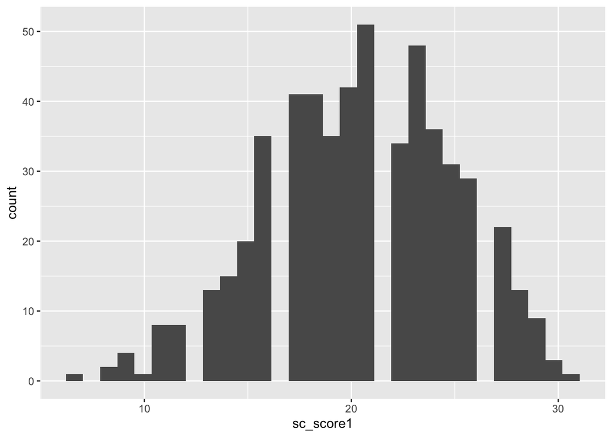

```r
df4 %>%
  ggplot(aes(x = sc_score1)) +
  geom_histogram()
```

# RPM (df5)

## Score

```r
df5 <- df4 %>%
  mutate(rav1_0 = ifelse(is.na(ravens1_b) == T, 0, ravens1_b),
         rav2_0 = ifelse(is.na(ravens2_b) == T, 0, ravens2_b),
         rav3_0 = ifelse(is.na(ravens3_b) == T, 0, ravens3_b),
         rav4_0 = ifelse(is.na(ravens4_b) == T, 0, ravens4_b),
         rav5_0 = ifelse(is.na(ravens5_b) == T, 0, ravens5_b),
         rav6_0 = ifelse(is.na(ravens6_b) == T, 0, ravens6_b),
         rav7_0 = ifelse(is.na(ravens7_b) == T, 0, ravens7_b),
         rav8_0 = ifelse(is.na(ravens8_b) == T, 0, ravens8_b),
         rav9_0 = ifelse(is.na(ravens9_b) == T, 0, ravens9_b),
         rav10_0 = ifelse(is.na(ravens10_b) == T, 0, ravens10_b),
         rav_scored = rav1_0 + rav2_0 + rav3_0 + rav4_0 + rav5_0 +
           rav6_0 + rav7_0 + rav8_0 + rav9_0 + rav10_0,
         rav_scoredz = scale(rav_scored))
```

## Exclude Outliers (df6)

```r
df5 %>%
  filter(rav_scoredz <= -3) %>%
  nrow()
```

```
## [1] 2
```

```r
df6 <- df5 %>%
  filter(rav_scoredz > -3)
```

## N (df6)

```r
df6 %>%
  group_by(con) %>%
  summarise(n = n())
```

```
## # A tibble: 3 × 2
##     con     n
##   <dbl> <int>
## 1    -1   265
## 2     0    51
## 3     1   226
```

## Descriptives

```r
df6$rav_scored %>%
  psych::describe()
```

```
##    vars   n mean   sd median trimmed  mad min max range  skew kurtosis   se
## X1    1 542 5.63 1.56      6    5.63 1.48   1  10     9 -0.09     0.41 0.07
```

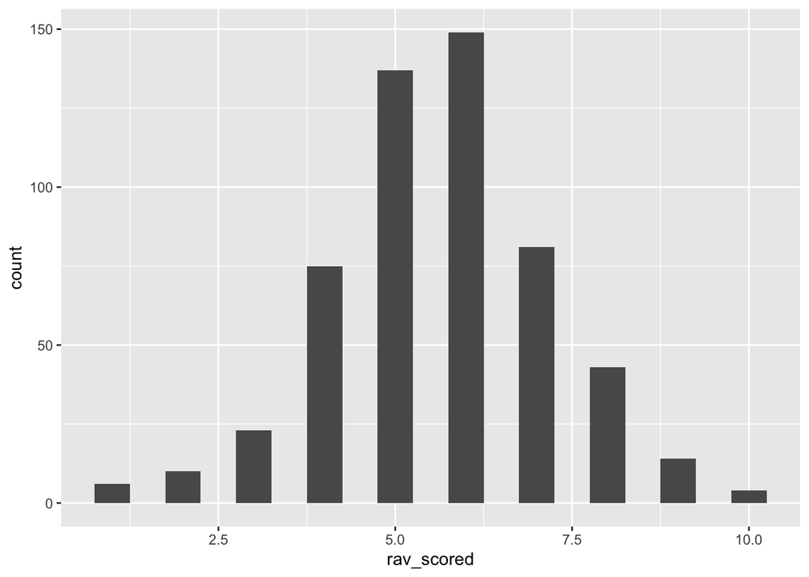

```r
df6 %>%
  ggplot(aes(x = rav_scored)) +
  geom_histogram(binwidth = .5)
```

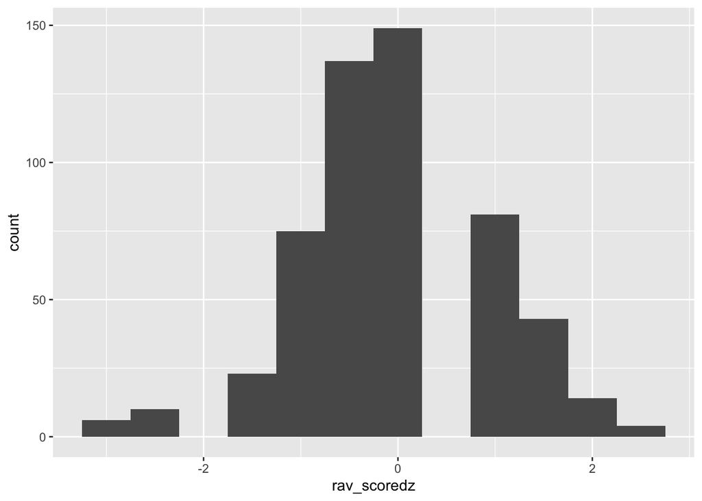

```r
df6 %>%
  ggplot(aes(x = rav_scoredz)) +
  geom_histogram(binwidth = .5)
```

Now excluding:

- Duplicates
- Unfinished
- Reported cheating
- Reported bad response
- Unapproved
- Did not consent
- Was not in both dfs (b and s1)
- **Outliers:**
  - Duration (1)
  - Science Curiosity (0)
  - Raven’s Progressive Matrices (2)

# MR Task (df7)

## Recode (-3 to 3)

```r
df7 <- df6 %>%
  mutate(arctic20 = dplyr::recode(arctic2_1_sc, `1` = -3,
                           `2` = -2,
                           `3` = -1,
                           `4` = 0,
                           `5` = 1,
                           `6` = 2,
                           `7` = 3),
         arctic20_z = scale(arctic20),
         temp20 = dplyr::recode(temp2_1_sc,`1` = 3,
                           `2` = 2,
                           `3` = 1,
                           `4` = 0,
                           `5` = -1,
                           `6` = -2,
                           `7` = -3),
         temp20_z = scale(temp20),
         ozone20 = dplyr::recode(ozone2_1_sc, `1` = -3,
                           `2` = -2,
                           `3` = -1,
                           `4` = 0,
                           `5` = 1,
                           `6` = 2,
                           `7` = 3),
         ozone20_z = scale(ozone20),
         airqual20 = dplyr::recode(air_qual2_1_sc, `1` = -3,
                           `2` = -2,
                           `3` = -1,
                           `4` = 0,
                           `5` = 1,
                           `6` = 2,
                           `7` = 3),
         airqual20_z = scale(airqual20),
         diatho20 = dplyr::recode(dia_tho2_1_sc, `1` = -3,
                           `2` = -2,
                           `3` = -1,
                           `4` = 0,
                           `5` = 1,
                           `6` = 2,
                           `7` = 3),
         diatho20_z = scale(diatho20),
         co220 = dplyr::recode(co22_1_sc, `1` = 3,
                           `2` = 2,
                           `3` = 1,
                           `4` = 0,
                           `5` = -1,
                           `6` = -2,
                           `7` = -3),
         co220_z = scale(co220),
         icesheets20 = dplyr::recode(ice_sheets2_1_sc, `1` = -3,
                           `2` = -2,
                           `3` = -1,
                           `4` = 0,
                           `5` = 1,
                           `6` = 2,
                           `7` = 3),
         icesheets20_z = scale(icesheets20),
         quake20 = if_else(quake2_1_sc == 4, 0, 1)
         )
```

## Recode (eb: 0 to 3)

```r
df7 <- df7 %>%
  mutate(arctic20_eb = dplyr::recode(arctic2_1_sc, `1` = 0,
                           `2` = 0,
                           `3` = 0,
                           `4` = 0,
                           `5` = 1,
                           `6` = 2,
                           `7` = 3),
         arctic20_eb_z = scale(arctic20_eb),
         temp20_eb = dplyr::recode(temp2_1_sc,`1` = 3,
                           `2` = 2,
                           `3` = 1,
                           `4` = 0,
                           `5` = 0,
                           `6` = 0,
                           `7` = 0),
         temp20_eb_z = scale(temp20_eb),
         ozone20_eb = dplyr::recode(ozone2_1_sc, `1` = 0,
                           `2` = 0,
                           `3` = 0,
                           `4` = 0,
                           `5` = 1,
                           `6` = 2,
                           `7` = 3),
         ozone20_eb_z = scale(ozone20_eb),
         airqual20_eb = dplyr::recode(air_qual2_1_sc, `1` = 0,
                           `2` = 0,
                           `3` = 0,
                           `4` = 0,
                           `5` = 1,
                           `6` = 2,
                           `7` = 3),
         airqual20_eb_z = scale(airqual20_eb),
         diatho20_eb = dplyr::recode(dia_tho2_1_sc, `1` = 0,
                           `2` = 0,
                           `3` = 0,
                           `4` = 0,
                           `5` = 1,
                           `6` = 2,
                           `7` = 3),
         diatho20_eb_z = scale(diatho20_eb),
         co220_eb = dplyr::recode(co22_1_sc, `1` = 3,
                           `2` = 2,
                           `3` = 1,
                           `4` = 0,
                           `5` = 0,
                           `6` = 0,
                           `7` = 0),
         co220_eb_z = scale(co220_eb),
         icesheets20_eb = dplyr::recode(ice_sheets2_1_sc, `1` = 0,
                           `2` = 0,
                           `3` = 0,
                           `4` = 0,
                           `5` = 1,
                           `6` = 2,
                           `7` = 3),
         icesheets20_eb_z = scale(icesheets20_eb),
         quake20_eb = if_else(quake2_1_sc == 4, 0, 1)
         )
```

## Recode (yn: 0 or 1)

```r
df7 <- df7 %>%
  mutate(arctic20_yn = dplyr::recode(arctic2_1_sc, `1` = 0,
                           `2` = 0,
                           `3` = 0,
                           `4` = 1,
                           `5` = 1,
                           `6` = 1,
                           `7` = 1),
         temp20_yn = dplyr::recode(temp2_1_sc,`1` = 1,
                           `2` = 1,
                           `3` = 1,
                           `4` = 1,
                           `5` = 0,
                           `6` = 0,
                           `7` = 0),
         ozone20_yn = dplyr::recode(ozone2_1_sc, `1` = 0,
                           `2` = 0,
                           `3` = 0,
                           `4` = 1,
                           `5` = 1,
                           `6` = 1,
                           `7` = 1),
         airqual20_yn = dplyr::recode(air_qual2_1_sc, `1` = 0,
                           `2` = 0,
                           `3` = 0,
                           `4` = 1,
                           `5` = 1,
                           `6` = 1,
                           `7` = 1),
         diatho20_yn = dplyr::recode(dia_tho2_1_sc, `1` = 0,
                           `2` = 0,
                           `3` = 0,
                           `4` = 1,
                           `5` = 1,
                           `6` = 1,
                           `7` = 1),
         co220_yn = dplyr::recode(co22_1_sc, `1` = 1,
                           `2` = 1,
                           `3` = 1,
                           `4` = 1,
                           `5` = 0,
                           `6` = 0,
                           `7` = 0),
         icesheets20_yn = dplyr::recode(ice_sheets2_1_sc, `1` = 0,
                           `2` = 0,
                           `3` = 0,
                           `4` = 1,
                           `5` = 1,
                           `6` = 1,
                           `7` = 1),
         quake20_yn = if_else(quake2_1_sc == 4, 0, 1)
         )
```